# STA243 Hw1 - Eric Kalosa-Kenyon

```r
library("ggplot2")          # fancy plotting
library("latex2exp")        # latex for plots
library("RColorBrewer")     # pretty colors
```

# 1

## 1.a

$p_n(x_1\dots x_n, \theta) = \prod_{i=1}^{n} p(x_i, \theta)$ where $p(x, \theta) = \frac{1}{\pi*(1+(x-\theta)^2)}$. Hence, $l_n(\theta) = \log{p_n(x_1\dots x_n, \theta)} = -n\log{\pi}-\sum_{i=1}^{n}{\log{1+(x_i-\theta)^2}}$

Further, $l_n^{'}(\theta) = \frac{\partial}{\partial \theta} l_n(\theta) = -\sum_{i=1}^{n} \frac{\partial}{\partial \theta} \log{1+(x_i-\theta)^2} = -2\sum_{i=1}^{n} \frac{\theta-x_i}{1+(x_i-\theta)^2}$.

Finally $l_n^{''}(\theta) = \frac{\partial^2}{\partial \theta^2} l_n(\theta) = \frac{\partial}{\partial \theta} l_n^{'}(\theta) = -2\sum_{i=1}^{n} \frac{1}{1+(x_i-\theta)^2} - (\theta-x_i)(1+(\theta-x_i)^2)^{-2}(2(\theta-x_i))$. Rewriting some terms, we find $l_n^{''}(\theta) = -2\sum_{i=1}^{n} \frac{1+(x_i-\theta)^2}{(1+(x_i-\theta)^2)^2} - \frac{-2(\theta-x_i)^2}{(1+(x_i-\theta)^2)^2}$ which simplifies to $l_n^{''}(\theta) = -2\sum_{i=1}^{n} \frac{1-(\theta-x_i)^2}{(1+(\theta-x_i)^2)^2}$ as desired.

## 1.b

The Fischer Information is calculated as follows: $I_n(\theta) = n*I(\theta)$. $I(\theta) = -E_\theta(l^{''}(\theta)) = -\int_{-\infty}^{\infty} p(x,\theta)*l^{''}(\theta) dx$. This simplifies to $\frac{2}{\pi} \int_{-\infty}^{\infty} \frac{1-(\theta-x)^2}{(1+(\theta-x)^2)^3} dx = \frac{2}{\pi} \frac{\pi}{4}$. Leveraging the first equality, we see that $I_n(\theta) = \frac{n}{2}$.

## 1.c

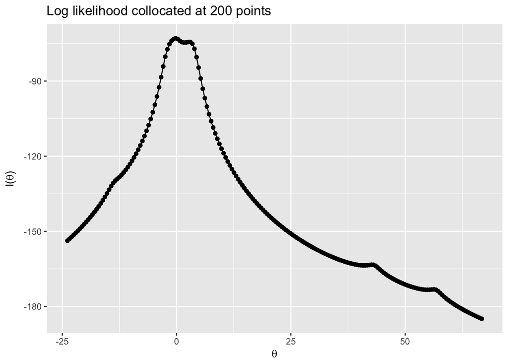

```r
p_1 = function(x, t){
    d = pi*(1+(x-t)^2)
    return(1/d)
}
l_1 = function(x, t){
    return(log(p_1(x,t)))
}
l_n = function(xs, t){
    r = 0
    for(x in xs){
        r = r + l_1(x, t)
    }
    return(r)
}

N = 200
raw = c(-13.87, -2.53, -2.44, -2.40, -1.75, -1.34, -1.05, -0.23, -0.07, 0.27,
        1.77, 2.76, 3.29, 3.47, 3.71, 3.80, 4.24, 4.53, 43.21, 56.75)
ts = seq(from=min(raw)-10, to=max(raw)+10, length=N)

df = data.frame(ts, l_n(xs=raw, t=ts))
names(df) = c("theta", "loglik")

g = qplot(df$theta, df$loglik) +
    geom_line() +
    ggtitle(paste("Log likelihood collocated at", N, "points")) +
    ylab(TeX("l($\\theta)")) + xlab(TeX("$\\theta"))
g
```

## 1.d

```r
xis = c(-11, -1, 0, 1.4, 4.1, 4.8, 7, 8, 38) # initial values for NR
eps = 0.001 # convergence criterion
delt = 0.0001 # increment parameter for derivatives

f_pdf = function(t){
    # Log likelihood given raw data as xs
    return(l_n(xs=raw, t=t))
}
fp = function(f, t, d){
    # first derivative aprox
    f0 = f(t-d/2)
    f1 = f(t+d/2)
    return((f1-f0)/d)
}
fpp = function(f, t, d){
    # second derivative aprox
    return(fp(fp(f, t, d), t, d))
}

nr_inc = function(f, x, d){
    # Increment x using the newton rhapson method
    return(x-f(x)/fp(f, x, d))
}

find_0s = function(f, x0, e, d, inc_fxn){
    # use NR to find a zero for the function
    x1 = inc_fxn(f, x0, d)
    while(abs(x1-x0)>e){
        # While we haven't converged, iterate the incrementing function (which
        # must have the signature [pdf, x, delta]) e.g. nr_inc
        x0 = x1
        x1 = inc_fxn(f, x0, d)

        # Check for algorithm failures and divergences
        if(is.na(x1)){
            return(Inf)
        }
        if(abs(x1)==Inf){
            # If the algorithm diverges, return Inf
            return(Inf)
        }
    }

    # If we've converged (abs(x1-x0)<e) then return the convergent value
    return(x1)
}

f_find_0 = function(t){
    # This is the function we're finding the 0's of
    # In this case, it's the first derivative of the log likelihood (f_pdf)
    return(fp(f_pdf, t, delt))
}

xmax = c() # holds results of NR algorithm, Inf when divergent
for(xi in xis){
    xmax = c(xmax, find_0s(f_find_0, xi, eps, delt, nr_inc))
}
```

The Newton-Rhapson method has found the following maxima for the initial values $-1, 0, 1.4, 4.1, 7, 38$: $-0.1922865, -0.1922866, 1.7135868, 2.8174735, 41.0408478, 42.7953779$. The initial values $-11, 4.8, 8$ begat divergent results with the tuning parameters used in this algorithm. These results show that the maximum found by N-R is local and depends heavily on the initial conditions when the pdf is multimodal as is the case in this example.

It is illustrative to examine the first derivative of the log likelihood function for insight on divergence conditions:

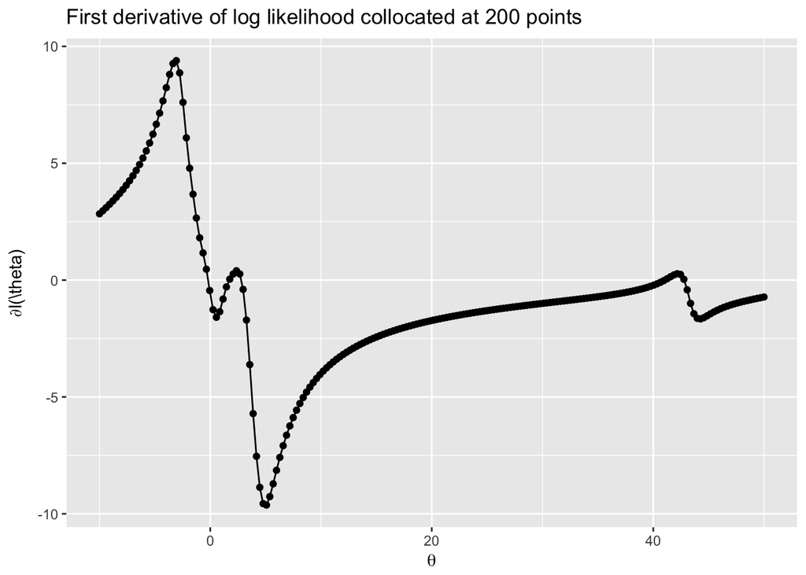

```r
N = 200
xss = seq(-10,50,length.out=N)
yss = f_find_0(xss)
df = data.frame(xss, yss)
g = qplot(df$xss, df$yss) +
    geom_line() +
    ggtitle(
        paste("First derivative of log likelihood collocated at",
              N,
              "points")) +
    ylab(TeX("$\\partial l($\\theta)")) +
    xlab(TeX("$\\theta"))
g
```

Note that N-R finds the obvious roots of the first derivative of the log likelihood function, but it diverges on the tails as it chases the 0’s at $\pm\infty$.

## 1.e

```r
fI = length(raw)/2  # I(\theta) = n/2 for the Cauchy dist.
fiscor_inc = function(f, x, d){
    # Increment x using the Fischer Scoring method
    return(x+f(x)/fI)
}
xmax = c() # holds results of FS algorithm, Inf when divergent
for(xi in xis){
    xmax = c(xmax, find_0s(f_find_0, xi, eps, delt, fiscor_inc))
}
```

The Fischer Scoring method has found the following maxima for the initial values $-11, -1, 0, 1.4, 4.1, 4.8, 7, 8, 38$: $-0.1939273, -0.1939695, -0.1900633, -0.1906264, 2.8203144, 2.8208646, 2.8207965, 2.8206372, 2.8206678$. There were no divergent results using the Fischer Scoring algorithm in this case, but it missed three apparent MLE candidate values. The MLE candidates found with the Fischer Scoring method are in agreement with a subset of the candidates proposed by the Newton-Rhapson method in 1.d above.

# 2

In this problem we examine the behavior of MLE convergence using the Newton Rhapson method in the context of the pdf $f_\theta(x) = \frac{1-\cos(x-\theta)}{2\pi}$ where $0\le x \le 2\pi$ and $-\pi\le\theta\le\pi$.

## 2.a

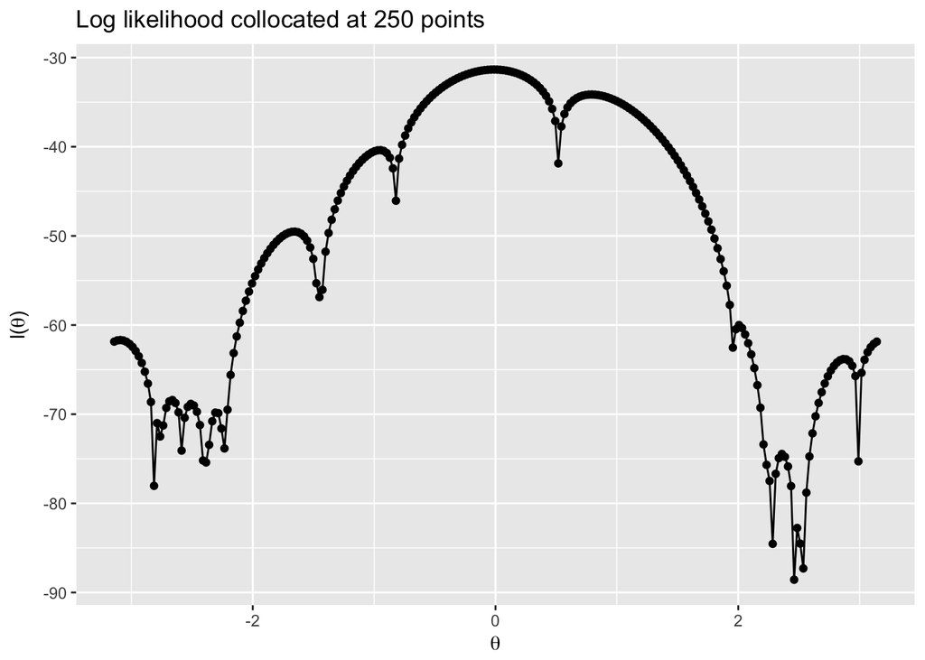

```r
raw = c(0.52, 1.96, 2.22, 2.28, 2.28, 2.46, 2.50, 2.53, 2.54, 2.99, 3.47, 3.53,
        3.70, 3.88, 3.91, 4.04, 4.06, 4.82, 4.85, 5.46)

p_1 = function(x, t){
    # Single dimensional pdf of x with parameter t

    # Domain checking
    if(x<0 || x>2*pi){
        return(0)
    }
    if(t< -pi || t>pi){
        return(0)
    }

    return((1-cos(x-t))/(2*pi))
}

l_n = function(xs, t){
    # multidimensional log likelihood for the above pdf
    r = 0
    for(x in xs){
        r = r + log(p_1(x, t))
    }
    return(r)
}

llik = function(t){
    # log likelihood above conditioned on observing the raw data above
    return(l_n(raw, t))
}

# Plot the loglikelihood
N = 250
ts = seq(from=-pi, to=pi, length=N)

df = data.frame(ts, llik(ts))
names(df) = c("theta", "loglik")

rm(g)
g = qplot(df$theta, df$loglik) +
    geom_line() +
    ggtitle(paste("Log likelihood collocated at", N, "points")) +
    ylab(TeX("l($\\theta)")) + xlab(TeX("$\\theta"))
g
```

## 2.c

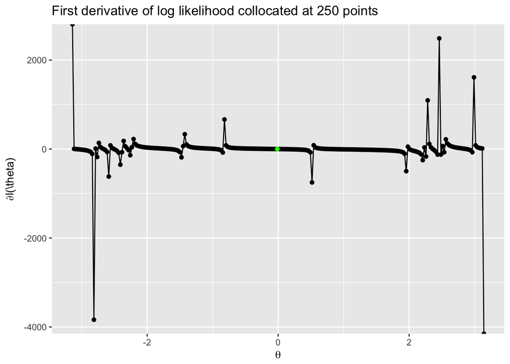

```r
# Find N-R solution for MLE with t0=MoM
eps = 0.001
delt = 0.001
t0 = asin(mean(raw) - pi)   # MoM estimate for t0
llikp = function(t){        # d/dt l(t)
    return(fp(llik, t, delt))
}
mle = find_0s(llikp, t0, eps, delt, nr_inc)     # Execute the N-R algorithm

# Plot d/dt l(t)
ts = seq(from=-pi, to=pi, length.out=N)
llikps = c()
for(t in ts){llikps = c(llikps, llikp(t))}
df = data.frame(ts, llikps)
names(df) = c("theta", "dldt")
df1 = data.frame(mle, 0)    # subsetting for highlighted plotting below
names(df1) = c("theta", "dldt")

rm(g)
g = qplot(df$theta, df$dldt) +
    geom_line() +
    geom_point(data=df1, aes(x=theta, y=dldt), colour="green") +
    ggtitle(paste("First derivative of log likelihood collocated at",
                  N, "points")) +
    ylab(TeX("$\\partial l($\\theta)")) + xlab(TeX("$\\theta"))
g
```

Using the initial value $\theta_0=\hat{\theta}_{MoM}=0.0584406$ for the Newton-Rhapson method, we find an MLE $\hat{\theta}_{MLE}=-0.011972$.

## 2.d

```r
t0s = c(-2.7, 2.7)
mles = c()
for(t0 in t0s){
    mle = find_0s(llikp, t0, eps, delt, nr_inc)
    mles = c(mles, mle)
}
```

Using the initial values $\theta_0\in\{-2.7, 2.7\}$ we find the MLEs $\hat{\theta}_{MLE}\in\{-2.6666999, 2.8730942\}$.

## 2.e

```r
N = 200
t0s = seq(from=-pi+delt, to=pi-delt, length.out=N)
mles = c()
# Calculate MLEs
for(t0 in t0s){
    mle = find_0s(llikp, t0, eps, delt, nr_inc)
    mles = c(mles, mle)
}

# Calculate "fuzzy" unique MLEs
mles_clean = mles[!mles==Inf]
umles = c()
eps = 0.01

for(m in mles_clean){
    if(length(umles)==0){umles=c(m)} # if there are no unique mles, add one
    uniq = TRUE
    for(u in umles){
        if(u+eps>m & u-eps<m){
            # if the proposed MLE is close to an already unique MLE, pass
            uniq = FALSE
        }
    }
    if(uniq){
        # If the proposed MLE (m) is not close to any of the established umles,
        # add it to the list of umles
        umles[length(umles)+1] = m
    }
}

# Determine which attractor each t0 is pulled to
df = data.frame(t0s, llik(t0s), mles, rep(0, length(mles)))
names(df) = c("t0", "llik", "mle", "group")
nu = 1
for(u in umles){
    for(i in 1:nrow(df)){
        m = df[i,]$mle
        if(m+eps>u & u-eps<u){
            df[i,]$group = nu
        }
        if(m==Inf){
            df[i,]$group = 0
        }
    }
    nu = nu + 1
}
df$group = as.factor(df$group)
```

We find 20 unique MLEs: -3.1405927, -3.0930917, -2.786166, -2.6667, -2.5076157, -2.3882005, -2.2972567, -2.2321423, -1.6582835, -1.4474795, -0.9533353, -0.0119719, 0.7906015, 2.0036463, 2.2362136, 2.3607183, 2.4753757, 2.5135815, 2.8730942, 3.1405927.

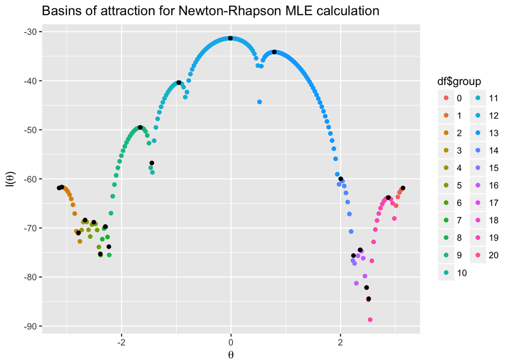

```r
df1 = data.frame(umles, rep(0,length(umles)))
names(df1) = c("mle", "llik")
df1$llik = llik(df1$mle)

g = qplot(df$t0, df$llik, color=df$group) +
    ggtitle("Basins of attraction for Newton-Rhapson MLE calculation") +
    ylab(TeX("l($\\theta)")) + xlab(TeX("$\\theta")) +
    geom_point(data=df1, aes(x=mle, y=llik), colour="black")
g
```

Each unique MLE estimate (in black) has a basin of attraction indicated by the colored groups depicted above.

# 3

## 3.a

```r
df = data.frame(
    x=c(0.02, 0.02, 0.06, 0.06, 0.11, 0.11, 0.22, 0.22, 0.56, 0.56, 1.10, 1.10),
    y=c(47, 76, 97, 107, 123, 139, 152, 159, 191, 201, 200, 207)
)

fit = lm(y~x, data=df)
b0 = fit$coefficients[1]
b1 = fit$coefficients[2]
t1 = 1/b0
t2 = b1*t1
```

Our simplified estimates for $\theta_1$ and $\theta_2$ are $\hat{\theta}_1=0.009663$ and $\hat{\theta}_2=1.0669934$.

## 3.b

To implement the multivariate Newton-Rhapson method, we must first calculate

$$g^{'}(\theta_1,\theta_2)=
\left( \begin{array}{cc}
\frac{\partial g}{\partial\theta_1} & \frac{\partial g}{\partial\theta_2} \end{array} \right)$$

$$g^{''}(\theta_1,\theta_2)=
\left( \begin{array}{cc}
\frac{\partial^2g}{\partial\theta_1^2} & \frac{\partial^2g}{\partial\theta_1\partial\theta_2} \\
\frac{\partial^2g}{\partial\theta_1\partial\theta_2} & \frac{\partial^2g}{\partial\theta_2^2} \end{array} \right)$$

where $g(\theta_1,\theta_2) = \sum_{i=1}^n (y_i-\frac{x_i\theta_1}{x_i+\theta_2})^2$. $\frac{\partial g}{\partial\theta_1} = \sum \frac{2x_i(\theta_1 x_i-y_i(x_i+\theta_2))}{(x_i+\theta_2)^2}$. $\frac{\partial g}{\partial\theta_2} = \sum \frac{2\theta_1 x_i(y_i(\theta_2+x_i)-\theta_1 x_i)}{(\theta_2+x_i)^3}$.

$\frac{\partial^2}{\partial\theta_1\partial\theta_2}g(\theta_1, \theta_2) = \sum -2x_i\frac{2\theta_1 x_i-y_i(x_i+\theta_2)}{(x+\theta_2)^3}$, $\frac{\partial^2}{\partial\theta_1^2}g(\theta_1, \theta_2) = \sum \frac{2x_i^2}{(x_i+\theta_2)^2}$, and $\frac{\partial^2}{\partial\theta_2^2}g(\theta_1, \theta_2) = \sum 2x_i\theta_1\frac{3x_i\theta_1-2y_i(\theta_2+x_i)}{(\theta_2+x_i)^4}$.

Now we have the tools to program the multivariate Newton-Rhapson method.

```r
# Define loss functions and its derivatives
g = function(t, x, y){
    # Multivariate OLS, requires type(x & y) = list(length=n), type(t)=list(2)
    r = y - (t[1]*x)/(t[2]+x)
    return(sum(r^2))
}

dgdt1 = function(t, x, y){
    t1 = t[1]
    t2 = t[2]
    r = 2*x*(t1*x-y*(x+t2))/(x+t2)^2
    return(sum(r))
}
dgdt2 = function(t, x, y){
    t1 = t[1]
    t2 = t[2]
    r = -2*t1*x*(t1*x-y*(t2+x))/(t2+x)^3
    return(sum(r))
}
ddgdt1dt2 = function(t, x, y){
    t1 = t[1]
    t2 = t[2]
    r = -2*x*(2*t1*x-y*(x+t2))/(x+t2)^3
    return(sum(r))
}
ddgdt12 = function(t, x, y){
    t1 = t[1]
    t2 = t[2]
    r = 2*x^2/(x+t2)^2
    return(sum(r))
}
ddgdt22 = function(t, x, y){
    t1 = t[1]
    t2 = t[2]
    r = 2*t1*x*(3*t1*x-2*y*(t2+x))/(t2+x)^4
    return(sum(r))
}

gp = function(t, x, y){
    g1 = dgdt1(t, x, y)
    g2 = dgdt2(t, x, y)
    return(c(g1, g2))
}
gpp = function(t, x, y){
    g11 = ddgdt12(t, x, y)
    g12 = ddgdt1dt2(t, x, y)
    g22 = ddgdt22(t, x, y)
    m = c(g11, g12, g12, g22)
    return(matrix(m, 2, 2))
}

# Define iteration function
nr_itt = function(t, x, y){
    gp1 = gp(t, x, y)
    gp2 = gpp(t, x, y)

    t1 = tryCatch({
        gp2inv = solve(gp2)
        r = t - gp2inv %*% gp1
        return(r)

    }, error = function(e) {
        print(e)
        r = c(Inf, Inf)
        return(r)

    })

    return(t1)
}

# Parameterize algorithm
# eps = 0.001 # convergence criteria for multidim. grad. desc. unclear
x = df$x
y = df$y
tn = c(t1, t2) # MoM as t_0
tnp1 = nr_itt(tn, x, y)

# Gradient descent
i = 0
maxitt = 1000
track = data.frame(
                   t1=rep(0, maxitt),
                   t2=rep(0, maxitt),
                   i=rep(0, maxitt))
track[1,] = c(tn, 1)
for(i in 1:maxitt){
    # i = i + 1
    tn = tnp1
    track[i,] = c(tn, i)
    tnp1 = nr_itt(tn, x, y)
    if(tnp1[1] == Inf){
        tnp1 = tn
        break
    }
}
```

```
## <simpleError in solve.default(gp2): Lapack routine dgesv: system is exactly singular: U[2,2] = 0>
```

The Newton-Rhapson method produces $\hat{\theta}_1=0$ and $\hat{\theta}_2=7.939679\times 10^{102}$.

This looks like a divergent solution, so we proceed to examine the behavior of the loss function graphically.

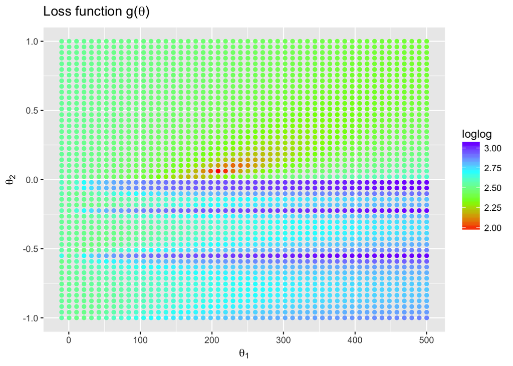

```r
# Numerical plotting the g()
ff = function(t1, t2){
    t = c(t1,t2)
    r = g(t, df$x, df$y)
}

N = 50
rngt1 = seq(-10, 500, length=N)
rngt2 = seq(-1, 1, length=N)
pltdf = data.frame(x=rep(0, N^2), y=rep(0, N^2), z=rep(0, N^2))

i = 1
for(x in rngt1){
    for(y in rngt2){
        r = c(x, y, ff(x, y))
        pltdf[i,] = r
        i = i + 1
    }
}

pltdf$loglog = log(log(pltdf$z))
plt = ggplot(pltdf, aes(x=x, y=y, color=loglog, z=z)) +
    geom_point() + # + geom_contour()
    ylab(TeX("$\\theta_2")) + xlab(TeX("$\\theta_1")) +
    scale_colour_gradientn(colours=rainbow(4)) +
    ggtitle(TeX("Loss function g($\\theta)"))
plt
```

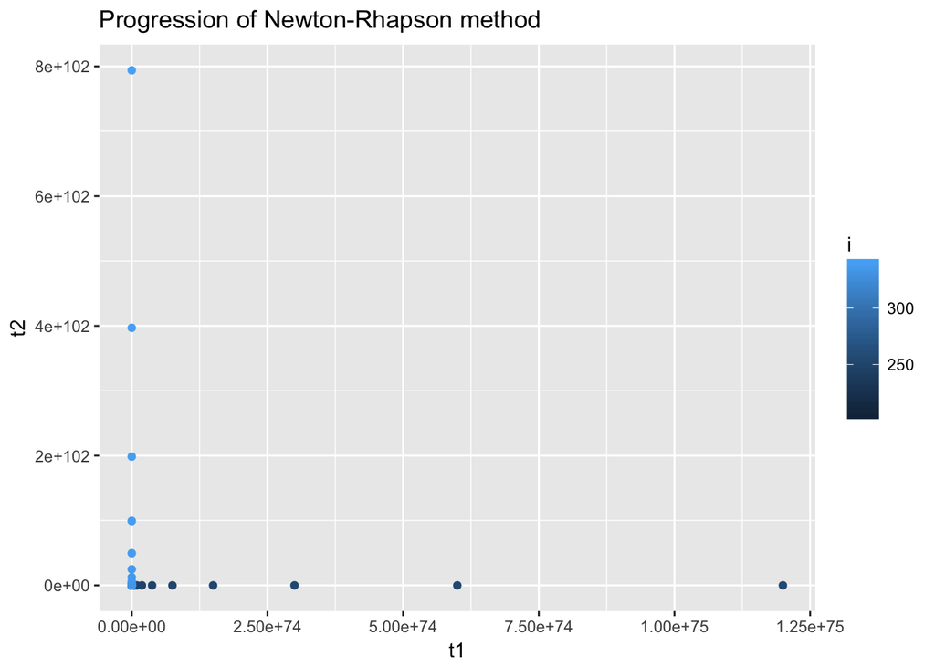

```r
plt2 =  ggplot(track[track$i>200,],
               aes(x=t1, y=t2, color=i)) + geom_point() +
    ggtitle("Progression of Newton-Rhapson method")
plt2
```

And from this result we can perform a quick grid search to compare with the Newton-Rhapson result as a sort of “sanity check”.

```r
inx = which(pltdf$z == min(pltdf$z))
tgrid = c(pltdf$x[inx], pltdf$y[inx])
```

The sanity check yields $\hat{\theta}_1=208.5714286$ and $\hat{\theta}_2=0.0612245$. Clearly the Newton-Rhapson solution here is indeed divergent, so we proceed to the following methods.

## 3.c

Using steepest descent,

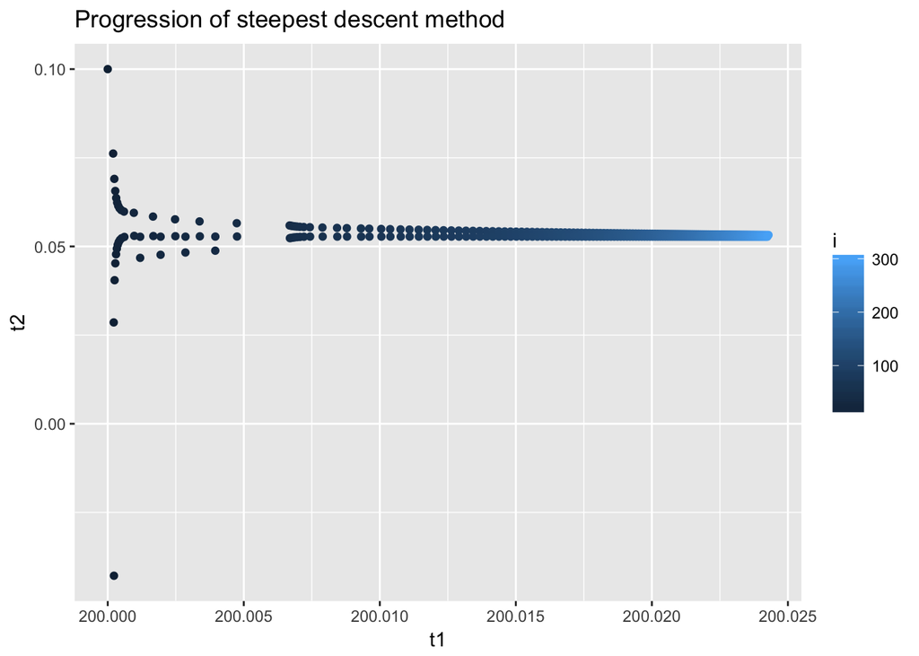

```r
nr_itt_sd = function(t, x, y, i){
    a = 1/(7*i)
    gp1 = gp(t, x, y)
    len = sqrt(sum(gp1^2))
    tsd = t - a*gp1/len
}

# Parameterize algorithm
eps = 0.0001
maxitt = 300
x = df$x
y = df$y
tn = c(0,0) # doesn't matter, gets set to tnp1 first thing in the loop
tnp1 = c(200, 0.1)

# Gradient descent using steepest descent
i = 0
track = data.frame(
                   t1=rep(0, maxitt),
                   t2=rep(0, maxitt),
                   i=rep(0, maxitt))
track[1,] = c(tnp1, 1)

while(i < maxitt & sum(abs(tn-tnp1)) > eps){
    i = i + 1
    tn = tnp1
    track[i,] = c(tn, i)
    tnp1 = nr_itt_sd(tn, x, y, i)
}

# print(track[track$i>0,])

plt3 =  ggplot(track[track$i>0,],
               aes(x=t1, y=t2, color=i)) + geom_point() +
    ggtitle("Progression of steepest descent method")
plt3
```

The steepest descent method produces $\hat{\theta}_1=200.0242855$ and $\hat{\theta}_2=0.0532257$. This result is consistent with our rough grid search estimate from part 3.b.